# Relatório em R Markdown

Lucas Araújo

2025-05-11

# Introdução

Este relatório apresenta uma análise simples de dados, visualização interativa com `DT`, equações matemáticas em LaTeX, imagens relacionadas à ciência de dados e referências bibliográficas.

# Manipulação de Dados (Item 1)

## Carregamento de Dados

Utilizaremos o conjunto de dados `mtcars`, já incluso no R.

```r
data(mtcars)
head(mtcars)
```

|  | mpg | cyl | disp | hp | drat | wt | qsec | vs | am | gear | carb |
| --- | --- | --- | --- | --- | --- | --- | --- | --- | --- | --- | --- |
| Mazda RX4 | 21.0 | 6 | 160 | 110 | 3.90 | 2.620 | 16.46 | 0 | 1 | 4 | 4 |
| Mazda RX4 Wag | 21.0 | 6 | 160 | 110 | 3.90 | 2.875 | 17.02 | 0 | 1 | 4 | 4 |
| Datsun 710 | 22.8 | 4 | 108 | 93 | 3.85 | 2.320 | 18.61 | 1 | 1 | 4 | 1 |
| Hornet 4 Drive | 21.4 | 6 | 258 | 110 | 3.08 | 3.215 | 19.44 | 1 | 0 | 3 | 1 |
| Hornet Sportabout | 18.7 | 8 | 360 | 175 | 3.15 | 3.440 | 17.02 | 0 | 0 | 3 | 2 |
| Valiant | 18.1 | 6 | 225 | 105 | 2.76 | 3.460 | 20.22 | 1 | 0 | 3 | 1 |

## Manipulação de Dados

Vamos ordenar os carros pelo consumo de combustível (`mpg`), filtrar os que têm 6 cilindros e criar uma nova variável `eficiencia` com base no `mpg`.

```r
library(dplyr)
mtcars_mod <- mtcars %>%
  mutate(model = rownames(mtcars)) %>%
  arrange(desc(mpg)) %>%
  filter(cyl == 6) %>%
  mutate(eficiencia = ifelse(mpg > 20, "Alta", "Média"))

mtcars_mod
```

|  | mpg | cyl | disp | hp | drat | wt | qsec | vs | am | gear | carb | model | eficiencia |
| --- | --- | --- | --- | --- | --- | --- | --- | --- | --- | --- | --- | --- | --- |
| Hornet 4 Drive | 21.4 | 6 | 258.0 | 110 | 3.08 | 3.215 | 19.44 | 1 | 0 | 3 | 1 | Hornet 4 Drive | Alta |
| Mazda RX4 | 21.0 | 6 | 160.0 | 110 | 3.90 | 2.620 | 16.46 | 0 | 1 | 4 | 4 | Mazda RX4 | Alta |
| Mazda RX4 Wag | 21.0 | 6 | 160.0 | 110 | 3.90 | 2.875 | 17.02 | 0 | 1 | 4 | 4 | Mazda RX4 Wag | Alta |
| Ferrari Dino | 19.7 | 6 | 145.0 | 175 | 3.62 | 2.770 | 15.50 | 0 | 1 | 5 | 6 | Ferrari Dino | Média |
| Merc 280 | 19.2 | 6 | 167.6 | 123 | 3.92 | 3.440 | 18.30 | 1 | 0 | 4 | 4 | Merc 280 | Média |
| Valiant | 18.1 | 6 | 225.0 | 105 | 2.76 | 3.460 | 20.22 | 1 | 0 | 3 | 1 | Valiant | Média |
| Merc 280C | 17.8 | 6 | 167.6 | 123 | 3.92 | 3.440 | 18.90 | 1 | 0 | 4 | 4 | Merc 280C | Média |

# Tabela Interativa (Item 2)

```r
library(DT)

datatable(mtcars_mod,
          options = list(pageLength = 5, autoWidth = TRUE),
          rownames = FALSE)
```

| mpg | cyl | disp | hp | drat | wt | qsec | vs | am | gear | carb | model | eficiencia |
| --- | --- | --- | --- | --- | --- | --- | --- | --- | --- | --- | --- | --- |
| 21.4 | 6 | 258 | 110 | 3.08 | 3.215 | 19.44 | 1 | 0 | 3 | 1 | Hornet 4 Drive | Alta |
| 21 | 6 | 160 | 110 | 3.9 | 2.62 | 16.46 | 0 | 1 | 4 | 4 | Mazda RX4 | Alta |
| 21 | 6 | 160 | 110 | 3.9 | 2.875 | 17.02 | 0 | 1 | 4 | 4 | Mazda RX4 Wag | Alta |
| 19.7 | 6 | 145 | 175 | 3.62 | 2.77 | 15.5 | 0 | 1 | 5 | 6 | Ferrari Dino | Média |
| 19.2 | 6 | 167.6 | 123 | 3.92 | 3.44 | 18.3 | 1 | 0 | 4 | 4 | Merc 280 | Média |
| 18.1 | 6 | 225 | 105 | 2.76 | 3.46 | 20.22 | 1 | 0 | 3 | 1 | Valiant | Média |
| 17.8 | 6 | 167.6 | 123 | 3.92 | 3.44 | 18.9 | 1 | 0 | 4 | 4 | Merc 280C | Média |

# Equações em LaTeX (Item 3)

## Equações e Significados

**1. Fórmula de regressão linear:**

$$y = \beta_0 + \beta_1 x + \varepsilon$$
*Representa a relação entre uma variável dependente `y` e uma independente `x`.*

**2. Gradiente descendente:**

$$\theta := \theta - \alpha \nabla J(\theta)$$
*Utilizado para minimizar funções de custo em aprendizado de máquina.*

**3. Entropia de Shannon:**

$$H(X) = - \sum_{i=1}^n p(x_i) \log p(x_i)$$
*Mede a incerteza de uma variável aleatória em teoria da informação.*

**4. Distribuição normal:**

$$f(x) = \frac{1}{\sqrt{2\pi\sigma^2}} e^{ -\frac{(x - \mu)^2}{2\sigma^2}
}$$
*Função densidade de probabilidade da normal com média `μ` e desvio padrão `σ`.*

**5. Matriz de covariância:**

$$\Sigma = E[(X - \mu)(X - \mu)^T]$$
*Representa como duas variáveis variam juntas.*

# Figuras (Item 4)

## Figura 1: Ciclo de Ciência de Dados

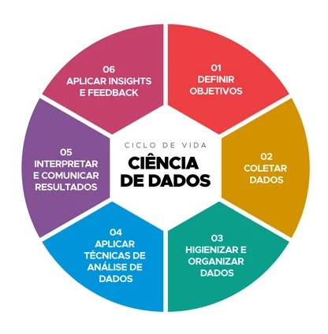

## Figura 2: Diagrama de Machine Learning

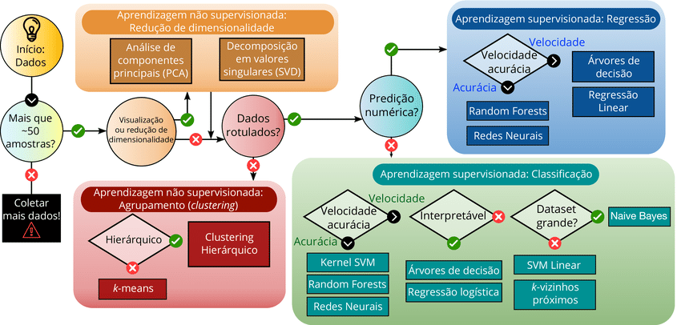

# Referências Bibliográficas (Item 5)

1. James, G., Witten, D., Hastie, T., & Tibshirani, R. (2021). *An Introduction to Statistical Learning*. Springer.
2. Kuhn, M., & Johnson, K. (2013). *Applied Predictive Modeling*. Springer.
3. Bishop, C. M. (2006). *Pattern Recognition and Machine Learning*. Springer.
4. Provost, F., & Fawcett, T. (2013). *Data Science for Business*. O’Reilly Media.
5. Murphy, K. P. (2012). *Machine Learning: A Probabilistic Perspective*. MIT Press.